# Multilevel Approaches to Modeling Growth and Change in Latent Variables

# Latent Growth Curve Model (LGCM)

## Modeling considerations: LGCM

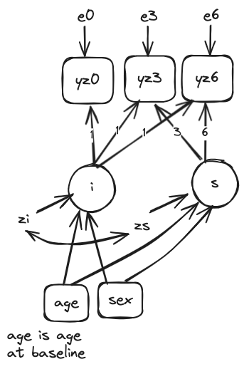

This is a typical LGCM for a univariate outcome.

For my first model, I’m going to use an outcome `yz` which is a baseline normalized z-score based on the observed items. It’s not a latent variable. But by normalizing at the baseline, it will give an approximation of the results we should expect when we move to the latent variable modeling framework.

`yz0`, `yz3`, and `yz6` are the normalized scores for the mean of 6 CESD questions observed at the baseline and 3 and 6 year follow-up of the EPESE.

Libraries

```r
library(tidyverse)
library(stringr)
library(devtools)
library(MplusAutomation)
```

## Wide data

```r
df.cesd <- df %>%
      select(which(names(df) %in% c("id", "t","yz","agec70","female"))) %>%
      pivot_wider(
         names_from = t,
         values_from = yz,
         names_prefix = "yz"
      )
```

**Descriptives of wide data**

```r
psych::describe(df.cesd, type = 3, skew = FALSE, ranges = TRUE, na.rm = TRUE)
```

```
       vars    n    mean     sd  median   min     max   range    se
id        1 2762 1401.29 810.50 1400.50  1.00 2812.00 2811.00 15.42
female    2 2762    0.58   0.49    1.00  0.00    1.00    1.00  0.01
agec70    3 2762    0.36   0.65    0.20 -0.30    1.70    2.00  0.01
yz0       4 2728    0.00   1.00   -0.38 -0.91    3.87    4.77  0.02
yz3       5 2015    0.03   1.01   -0.27 -0.91    3.87    4.77  0.02
yz6       6 1422    0.08   1.03   -0.11 -0.91    3.87    4.77  0.03
```

**Use MplusAutomation to prepare data set for Mplus**

```r
MplusAutomation::prepareMplusData(df.cesd,"cesd.dat")
```

```
TITLE: Your title goes here
DATA: FILE = "cesd.dat";
VARIABLE:
NAMES = id female agec70 yz0 yz3 yz6;
MISSING=.;
```

## Mplus ordinary LGC model

```
TITLE:    LGCM CESD score
DATA:     FILE = cesd.dat ;
VARIABLE: NAMES = id female agec70 yz0 yz3 yz6;
          IDVARIABLE = id ;
          MISSING = . ;
MODEL:    i s | yz0@0 yz3@0.3 yz6@0.6 ; ! 10 year units
          yz0-yz6 (e) ;
          i s on agec70 female ;
```

```
Mplus VERSION 8.11 (Mac)
MUTHEN & MUTHEN
05/03/2025  12:55 PM

INPUT INSTRUCTIONS

  TITLE:    LGCM CESD score
  DATA:     FILE = cesd.dat ;
  VARIABLE: NAMES = id female agec70 yz0 yz3 yz6;
            IDVARIABLE = id ;
            MISSING = . ;
  MODEL:    i s | yz0@0 yz3@0.3 yz6@0.6 ; ! 10 year units
            yz0-yz6 (e) ;
            i s on agec70 female ;



INPUT READING TERMINATED NORMALLY



LGCM CESD score

SUMMARY OF ANALYSIS

Number of groups                                                 1
Number of observations                                        2762

Number of dependent variables                                    3
Number of independent variables                                  2
Number of continuous latent variables                            2

Observed dependent variables

  Continuous
   YZ0         YZ3         YZ6

Observed independent variables
   FEMALE      AGEC70

```

[output cut: 158 more lines]

```
        Ending Time:  12:55:14
       Elapsed Time:  00:00:00



MUTHEN & MUTHEN
3463 Stoner Ave.
Los Angeles, CA  90066

Tel: (310) 391-9971
Fax: (310) 391-8971
Web: www.StatModel.com
Support: Support@StatModel.com

Copyright (c) 1998-2024 Muthen & Muthen
```

**Save output from Mplus Engine**

```r
file.copy("formplus.out", "401-model1.out", overwrite = TRUE)
file.copy("formplus.inp", "401-model1.inp", overwrite = TRUE)
```

# Multilevel model for change

## LGCM vs Multilevel model

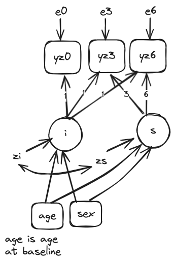

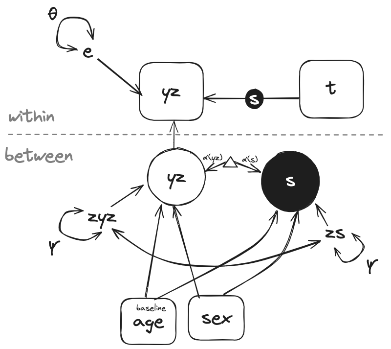

Next I’ll look at a multilevel modeling approach to measuring change in CESD symptoms. This means using the data in LONG format (rather than WIDE in the LGCM). Still looking at a standardized z-score for CESD symptoms: no latents yet for CESD.

**Data setup**

```r
df.cesd <- df %>%
      select(which(names(df) %in% c("id", "td","yz","agec70","female")))
psych::describe(df.cesd, type = 3, skew = FALSE, ranges = TRUE, na.rm = TRUE)
```

```
       vars    n    mean     sd  median   min     max   range    se
id        1 6165 1391.95 811.09 1393.00  1.00 2812.00 2811.00 10.33
td        2 6165    0.24   0.24    0.30  0.00    0.60    0.60  0.00
yz        3 6165    0.03   1.01   -0.11 -0.91    3.87    4.77  0.01
female    4 6165    0.60   0.49    1.00  0.00    1.00    1.00  0.01
agec70    5 6165    0.30   0.62    0.20 -0.30    1.70    2.00  0.01
```

**Use MplusAutomation to prepare data set for Mplus**

```r
MplusAutomation::prepareMplusData(df.cesd,"cesd.dat")
```

```
TITLE: Your title goes here
DATA: FILE = "cesd.dat";
VARIABLE:
NAMES = id td yz female agec70;
MISSING=.;
```

## Mplus Multilevel model

```
TITLE:    MLM CESD score
DATA:     FILE = cesd.dat ;
VARIABLE: NAMES = id td yz female agec70;
          MISSING = . ;
          WITHIN = td ;
          BETWEEN = agec70 female ;
          CLUSTER = id ;
ANALYSIS: TYPE = TWOLEVEL RANDOM ;
OUTPUT: TECH1;
MODEL:    %WITHIN%
            s | yz on td ;
          %BETWEEN%
            yz on agec70 female ;
            s on agec70 female ;
            yz with s ;
```

[output not shown]

[output cut: 322 more lines]

```
        Ending Time:  12:55:14
       Elapsed Time:  00:00:00



MUTHEN & MUTHEN
3463 Stoner Ave.
Los Angeles, CA  90066

Tel: (310) 391-9971
Fax: (310) 391-8971
Web: www.StatModel.com
Support: Support@StatModel.com

Copyright (c) 1998-2024 Muthen & Muthen
```

## Collect fits

```r
model1Results <- MplusAutomation::readModels(target="401-model1.out")
model2Results <- MplusAutomation::readModels(target="401-model2.out")
Fits <- MplusAutomation::SummaryTable(list(model1Results, model2Results),
         keepCols = c("Title","Parameters","NDependentVars",
                      "NContinuousLatentVars","Observations","LL", "AIC", "BIC", "ChiSqM_Value",
                      "ChiSqM_DF","RMSEA_Estimate","SRMR","CFI"))
FitsT <- as.data.frame(t(Fits))
# Add the variable names as the first column
FitsT$Feature <- rownames(FitsT)
# Adjust the column names
colnames(FitsT) <- c("Model 1", "Model 2", "Feature")
# Reset the rownames
rownames(FitsT) <- NULL
# Reorder
FitsT <- FitsT[c("Feature", "Model 1", "Model 2")]
```

## Compare fits

| Feature | Model 1 | Model 2 |
| --- | --- | --- |
| Title | LGCM CESD score | MLM CESD score |
| Parameters | 10 | 10 |
| NDependentVars | 3 | 1 |
| NContinuousLatentVars | 2 | 1 |
| Observations | 2762 | 6165 |
| LL | -8447.12 | -8447.12 |
| AIC | 16914.24 | 16914.24 |
| BIC | 16973.48 | 16981.51 |
| ChiSqM_Value | 6.378 | NA |
| ChiSqM_DF | 5 | NA |
| RMSEA_Estimate | 0.01 | NA |
| SRMR | 0.013 | NA |
| CFI | 0.998 | NA |

These models are equivalent by LL. The BICs are discussed on the next slide.

**About fits**

If you just looked at the BIC, you might think that there was a small advantage for LGCM over MLM. But the loglikelihood ($LL$) parameters reveal these models are equivalent. The BIC advantage comes from how the sample size is calculated.

Let’s compare parameter estimates and see what’s the same and what’s different.

```r
LGCM_parameters <- model1Results$parameters$unstandardized %>% mutate(PARAMETER = str_c(paramHeader,param, sep = " "))
MLM_parameters <-  model2Results$parameters$unstandardized %>% mutate(PARAMETER = str_c(paramHeader,param, sep = " "))
combinedParameters <- bind_rows(LGCM_parameters, MLM_parameters)
```

BY parameters

| paramHeader | param | est | se | est_se | pval | PARAMETER | BetweenWithin |
| --- | --- | --- | --- | --- | --- | --- | --- |
| I.\| | YZ0 | 1.0 | 0 | 999 | 999 | I.\| YZ0 | NA |
| I.\| | YZ3 | 1.0 | 0 | 999 | 999 | I.\| YZ3 | NA |
| I.\| | YZ6 | 1.0 | 0 | 999 | 999 | I.\| YZ6 | NA |
| S.\| | YZ0 | 0.0 | 0 | 999 | 999 | S.\| YZ0 | NA |
| S.\| | YZ3 | 0.3 | 0 | 999 | 999 | S.\| YZ3 | NA |
| S.\| | YZ6 | 0.6 | 0 | 999 | 999 | S.\| YZ6 | NA |

If the column `BetweenWithin` is `NA`, that means the result is from the LGCM.

Means and Intercepts parameters

| paramHeader | param | est | se | est_se | pval | PARAMETER | BetweenWithin |
| --- | --- | --- | --- | --- | --- | --- | --- |
| Intercepts | YZ0 | 0.000 | 0.000 | 999.000 | 999.000 | Intercepts YZ0 | NA |
| Intercepts | YZ3 | 0.000 | 0.000 | 999.000 | 999.000 | Intercepts YZ3 | NA |
| Intercepts | YZ6 | 0.000 | 0.000 | 999.000 | 999.000 | Intercepts YZ6 | NA |
| Intercepts | I | -0.177 | 0.030 | -5.871 | 0.000 | Intercepts I | NA |
| Intercepts | S | 0.196 | 0.075 | 2.607 | 0.009 | Intercepts S | NA |
| Intercepts | YZ | -0.177 | 0.027 | -6.598 | 0.000 | Intercepts YZ | Between |
| Intercepts | S | 0.196 | 0.069 | 2.847 | 0.004 | Intercepts S | Between |

The intercepts for the LEVEL (`Intercept I` for LGCM model and `Intercept YZ` for the MLM model) are the same, but the standard errors are smaller for the MLM model. Sme for the intercepts for the SLOPES.

Variances parameters

| paramHeader | param | est | se | est_se | pval | PARAMETER | BetweenWithin |
| --- | --- | --- | --- | --- | --- | --- | --- |
| Residual.Variances | YZ0 | 0.595 | 0.021 | 28.943 | 0.000 | Residual.Variances YZ0 | NA |
| Residual.Variances | YZ3 | 0.595 | 0.021 | 28.943 | 0.000 | Residual.Variances YZ3 | NA |
| Residual.Variances | YZ6 | 0.595 | 0.021 | 28.943 | 0.000 | Residual.Variances YZ6 | NA |
| Residual.Variances | I | 0.400 | 0.031 | 12.916 | 0.000 | Residual.Variances I | NA |
| Residual.Variances | S | 0.327 | 0.183 | 1.788 | 0.074 | Residual.Variances S | NA |
| Residual.Variances | YZ | 0.595 | 0.028 | 21.362 | 0.000 | Residual.Variances YZ | Within |
| Residual.Variances | YZ | 0.400 | 0.040 | 9.943 | 0.000 | Residual.Variances YZ | Between |
| Residual.Variances | S | 0.328 | 0.220 | 1.493 | 0.135 | Residual.Variances S | Between |

By constraining the residual variances to be equal in the LGCM, we obtain the same results set in the LGCM as the MLM model. For these parameters the standard errors are smaller for the LGCM model.

# Multilevel factor model

Now I’ll turn to latent variable modeling for depression.

First I’ll use a multilevel confirmatory factor analysis model (MLCFA). Many examples of this kind of a model can be found in the literature. However, this model comes with some difficulties. A factor measurement model must be specified at the WITHIN and BETWEEN level. These need not be the same, but I am ignorant regarding guidance on whether, how, and why these measurement models should be different. I keep them the same.

Additionally, the MLCFA model allows for residual variances at the factor indicator level to be distributed at the WITHIN and BETWEEN levels. I am just as confused about what to do about that. As I will describe, I don’t allow for factor indicator residual variances at the BETWEEN level in my parameterization.

## Modeling considerations: MLCFA

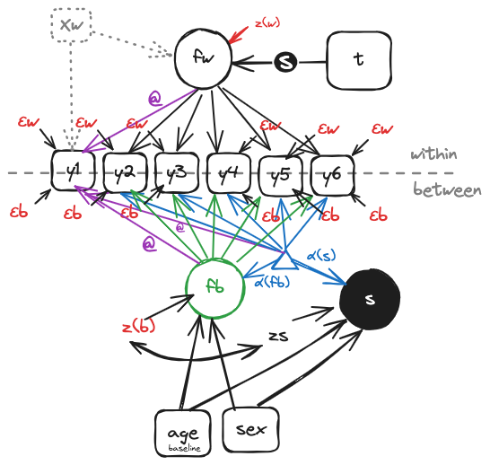

This is the model set-up for the multilevel factor analysis with regression on time in study as a random effect. Observed indicators of depression (y1-y6) are both within and between level variables (and not specified as WITHIN or BETWEEN). A within-level factor is specified (fw) that is identified by fixing the first factor loading (I run a series of preliminary models to find the factor loading that returns a total, single-level, baseline-only common latent variable variance of 1.0, and fix to that value). The fixed parameters are shown in purlple with “@” label. fw is regressed on time and this is declared a random effect. If we had within-level (i.e., time-varying) covariates, we would include them as illustrated with the dashed box and regressions “xw”.

At the between level, I have a between level common latent variable (fb). We assume the factor loadings at the between level and within level are equal. (This assumption is not necessary but I don’t have a reason to do anything else. I am not sure of the implications of having the measurement slopes be equal versus different at the BETWEEN and WITHIN levels). The item intercepts are modeled at the BETWEEN level. All but one are freely estimated. I fix one so that a mean for fb will be identified. The value to which the first item intercept is fixed is derived from the same preliminary models described previously for setting the metric of the factor loadings. The first item intercept is fixed to a value that returns a latent variable mean of 0 at baseline in a single level baseline only model.

The indicators have residual variances at the WITHIN and BETWEEN levels. I will fix these to 0 at the BETWEEN level because I am concerned that not doing so will rob the latent slope S of variance. But, we may have to play around with that.

**Data setup**

```r
items <- c("sad", "blues", "depress", "happy", "enjoy", "hopeful")
df.cesd <- df %>%
      select(which(names(df) %in% c("id", "td",items,"agec70","female")))
# Create new variables y1-y6 that correspond to the variables in items
for (i in seq_along(items)) {
  df.cesd[[paste0("y", i)]] <- df.cesd[[items[i]]]
}
df.cesd <- df.cesd %>%  select(-all_of(items))
```

**Descriptives for MLFA data**

```r
psych::describe(df.cesd, type = 3, skew = FALSE, ranges = TRUE, na.rm = TRUE)
```

```
       vars    n    mean     sd median  min    max  range    se
id        1 6165 1391.95 811.09 1393.0  1.0 2812.0 2811.0 10.33
td        2 6165    0.24   0.24    0.3  0.0    0.6    0.6  0.00
female    3 6165    0.60   0.49    1.0  0.0    1.0    1.0  0.01
agec70    4 6165    0.30   0.62    0.2 -0.3    1.7    2.0  0.01
y1        5 6119    1.47   0.75    1.0  1.0    4.0    3.0  0.01
y2        6 6109    1.35   0.74    1.0  1.0    4.0    3.0  0.01
y3        7 6130    1.52   0.82    1.0  1.0    4.0    3.0  0.01
y4        8 6071    1.70   1.00    1.0  1.0    4.0    3.0  0.01
y5        9 6063    1.54   0.94    1.0  1.0    4.0    3.0  0.01
y6       10 5693    1.94   1.19    1.0  1.0    4.0    3.0  0.02
```

**Use MplusAutomation to prepare data set for Mplus**

```r
MplusAutomation::prepareMplusData(df.cesd,"cesd.dat")
```

```
TITLE: Your title goes here
DATA: FILE = "cesd.dat";
VARIABLE:
NAMES = id td female agec70 y1 y2 y3 y4 y5 y6;
MISSING=.;
```

**Preliminary model 1**

Find the measurement slope at baseline for y1 such that the factor has a variance of 1.

First step: find R-squared for fw

```
Mplus VERSION 8.11 (Mac)
MUTHEN & MUTHEN
05/03/2025  12:55 PM

INPUT INSTRUCTIONS

  TITLE:    MLFA Preliminary Model 1
  DATA:     FILE = cesd.dat ;
  VARIABLE: NAMES = id t female agec70 y1 y2 y3 y4 y5 y6 ;
            USEVARIABLES = female agec70 y1-y6 ;
            USEOBSERVATIONS = (t==0) ;
            MISSING = . ;
  OUTPUT:   STDYX ; TECH4 ; SVALUES;
  MODEL:    fw by y1-y6* (l1-l6);
            fw@1;
            fw on female agec70 ;



INPUT READING TERMINATED NORMALLY



MLFA Preliminary Model 1

SUMMARY OF ANALYSIS

Number of groups                                                 1
Number of observations                                        2728

Number of dependent variables                                    6
Number of independent variables                                  2
Number of continuous latent variables                            1

Observed dependent variables

  Continuous
   Y1          Y2          Y3          Y4          Y5          Y6

Observed independent variables
```

[output cut: 333 more lines]

```
        Ending Time:  12:55:15
       Elapsed Time:  00:00:00



MUTHEN & MUTHEN
3463 Stoner Ave.
Los Angeles, CA  90066

Tel: (310) 391-9971
Fax: (310) 391-8971
Web: www.StatModel.com
Support: Support@StatModel.com

Copyright (c) 1998-2024 Muthen & Muthen
```

**Save and read results from first preliminary model**

```r
file.copy("formplus.out", "401-prelim1.out", overwrite = TRUE)
file.copy("formplus.inp", "401-prelim1.inp", overwrite = TRUE)
prelim1Results <- MplusAutomation::readModels(target="401-prelim1.out")
```

**Find the R-squared**

```r
r2fw <- prelim1Results$parameters$r2$est[prelim1Results$parameters$r2$param=="FW"]
resvar.fw <- 1-r2fw
resvar.fw
```

```
[1] 0.976
```

**Second step: constrain residual variance of fw to 1-Rsquared, and check TECH4**

```
Mplus VERSION 8.11 (Mac)
MUTHEN & MUTHEN
05/03/2025  12:55 PM

INPUT INSTRUCTIONS

  TITLE:    MLFA Preliminary Model 2
  DATA:     FILE = cesd.dat ;
  VARIABLE: NAMES = id t female agec70 y1 y2 y3 y4 y5 y6 ;
            USEVARIABLES = female agec70 y1-y6 ;
            USEOBSERVATIONS = (t==0) ;
            MISSING = . ;
  OUTPUT:   STDYX ; TECH4 ; SVALUES;
  MODEL:    fw by y1-y6* (l1-l6);
            fw@0.976; !1-R-squared
            fw on female agec70 ;



INPUT READING TERMINATED NORMALLY



MLFA Preliminary Model 2

SUMMARY OF ANALYSIS

Number of groups                                                 1
Number of observations                                        2728

Number of dependent variables                                    6
Number of independent variables                                  2
Number of continuous latent variables                            1

Observed dependent variables

  Continuous
   Y1          Y2          Y3          Y4          Y5          Y6

Observed independent variables
```

[output cut: 333 more lines]

```
        Ending Time:  12:55:15
       Elapsed Time:  00:00:00



MUTHEN & MUTHEN
3463 Stoner Ave.
Los Angeles, CA  90066

Tel: (310) 391-9971
Fax: (310) 391-8971
Web: www.StatModel.com
Support: Support@StatModel.com

Copyright (c) 1998-2024 Muthen & Muthen
```

```r
file.copy("formplus.out", "401-prelim2.out", overwrite = TRUE)
file.copy("formplus.inp", "401-prelim2.inp", overwrite = TRUE)
prelim2Results <- MplusAutomation::readModels(target="401-prelim2.out")
```

**Check TECH4 to make sure variance of FW is 1**

```r
prelim2Results$tech4$latCovEst
```

```
          FW FEMALE AGEC70
FW     1.000     NA     NA
FEMALE 0.068  0.243     NA
AGEC70 0.050  0.013  0.418
```

**Loading and Intercept for item 1**

```r
SVALUES <- readSvalues("401-prelim2.out")
SVALUES[ grep("y1", SVALUES)]
```

```
[1] "     fw BY y1*0.51150 (l1);" "     [ y1*1.35775 ];"
[3] "     y1*0.28463;"
```

**Third step: constrain factor loading in y1, free residual variance of fw, and check TECH4**

```
Mplus VERSION 8.11 (Mac)
MUTHEN & MUTHEN
05/03/2025  12:55 PM

INPUT INSTRUCTIONS

  TITLE:    MLFA Preliminary Model 3
  DATA:     FILE = cesd.dat ;
  VARIABLE: NAMES = id t female agec70 y1 y2 y3 y4 y5 y6 ;
            USEVARIABLES = female agec70 y1-y6 ;
            USEOBSERVATIONS = (t==0) ;
            MISSING = . ;
  OUTPUT:   STDYX ; TECH4 ;
  MODEL:    fw BY y1@0.51150 (l1);
            fw by y2-y6* (l2-l6);
            fw*;
            fw on female agec70 ;
            [y1@1.35775];
            [fw*];



INPUT READING TERMINATED NORMALLY



MLFA Preliminary Model 3

SUMMARY OF ANALYSIS

Number of groups                                                 1
Number of observations                                        2728

Number of dependent variables                                    6
Number of independent variables                                  2
Number of continuous latent variables                            1

Observed dependent variables

  Continuous
```

[output cut: 309 more lines]

```
        Ending Time:  12:55:15
       Elapsed Time:  00:00:00



MUTHEN & MUTHEN
3463 Stoner Ave.
Los Angeles, CA  90066

Tel: (310) 391-9971
Fax: (310) 391-8971
Web: www.StatModel.com
Support: Support@StatModel.com

Copyright (c) 1998-2024 Muthen & Muthen
```

```r
file.copy("formplus.out", "401-prelim3.out", overwrite = TRUE)
file.copy("formplus.inp", "401-prelim3.inp", overwrite = TRUE)
prelim3Results <- MplusAutomation::readModels(target="401-prelim3.out")
```

**Check TECH4 to make sure variance of FW is 1**

```r
prelim3Results$tech4$latCovEst
```

```
          FW FEMALE AGEC70
FW     1.000     NA     NA
FEMALE 0.068  0.243     NA
AGEC70 0.050  0.013  0.418
```

## MLFA

```
TITLE:    MLFA CESD EPESE
DATA:     FILE = cesd.dat ;
VARIABLE: NAMES = id t female agec70 y1 y2 y3 y4 y5 y6 ;
          MISSING = . ;
          WITHIN = t ;
          BETWEEN = agec70 female ;
          CLUSTER = id ;
ANALYSIS: TYPE = TWOLEVEL RANDOM ;
MODEL:    %WITHIN%
            fw BY y1@0.51150 (l1);
            fw by y2-y6* (l2-l6);
            s | fw on t ;
          %BETWEEN%
            fb BY y1@0.51150 (l1);
            fb by y2-y6* (l2-l6);
            y1-y6@0;
            fb on agec70 female ;
            s on agec70 female ;
            fb with s ;
            [y1@1.35775];
            [fb*];
```

```
Mplus VERSION 8.11 (Mac)
MUTHEN & MUTHEN
05/03/2025  12:55 PM

INPUT INSTRUCTIONS

  TITLE:    MLFA CESD EPESE
  DATA:     FILE = cesd.dat ;
  VARIABLE: NAMES = id t female agec70 y1 y2 y3 y4 y5 y6 ;
            MISSING = . ;
            WITHIN = t ;
            BETWEEN = agec70 female ;
            CLUSTER = id ;
  ANALYSIS: TYPE = TWOLEVEL RANDOM ;
  MODEL:    %WITHIN%
              fw BY y1@0.51150 (l1);
              fw by y2-y6* (l2-l6);
              s | fw on t ;
            %BETWEEN%
              fb BY y1@0.51150 (l1);
              fb by y2-y6* (l2-l6);
              y1-y6@0;
              fb on agec70 female ;
              s on agec70 female ;
              fb with s ;
              [y1@1.35775];
              [fb*];




*** WARNING
  One or more individual-level variables have no variation within a
  cluster for the following clusters.

     Variable   Cluster IDs with no within-cluster variation

      Y1          154 319 484 815 1046 1528 1791 2164 2451 557 762 765 1458 767 1460 1466 769
                  770 1476 50 1482 1483 776 404 1496 1497 1498 1503 1507 210 786 787 1526 790
                  1534 792 1538 413 420 1546 1551 797 800 1558 1563 425 1575 96 1578 814 1581
```

[output cut: 554 more lines]

```
        Ending Time:  12:55:16
       Elapsed Time:  00:00:01



MUTHEN & MUTHEN
3463 Stoner Ave.
Los Angeles, CA  90066

Tel: (310) 391-9971
Fax: (310) 391-8971
Web: www.StatModel.com
Support: Support@StatModel.com

Copyright (c) 1998-2024 Muthen & Muthen
```

**Save output**

```r
file.copy("formplus.out", "401-mlfa.out", overwrite = TRUE)
```

```
[1] TRUE
```

```r
file.copy("formplus.inp", "401-mlfa.inp", overwrite = TRUE)
```

```
[1] TRUE
```

```r
mlfaResults <- MplusAutomation::readModels(target="401-mlfa.out")
MLFA_parameters <-  mlfaResults$parameters$unstandardized %>%
   mutate(PARAMETER = str_c(paramHeader,param, sep = " "))
```

```r
mlfaResults$output[grep("Elapsed Time:",mlfaResults$output)]
```

```
[1] "       Elapsed Time:  00:00:01"
```

**Compare MLM and MLFA**

```r
MLFA_parameters$model <- "MLFA"
MLM_parameters$model <- "MLM"
combinedParameters <- bind_rows(MLM_parameters,MLFA_parameters)
```

BY parameters

| paramHeader | param | est | se | est_se | pval | BetweenWithin | PARAMETER | model |
| --- | --- | --- | --- | --- | --- | --- | --- | --- |
| FW.BY | Y1 | 0.512 | 0.000 | 999.000 | 999 | Within | FW.BY Y1 | MLFA |
| FW.BY | Y2 | 0.504 | 0.015 | 33.522 | 0 | Within | FW.BY Y2 | MLFA |
| FW.BY | Y3 | 0.608 | 0.016 | 38.119 | 0 | Within | FW.BY Y3 | MLFA |
| FW.BY | Y4 | 0.606 | 0.023 | 26.600 | 0 | Within | FW.BY Y4 | MLFA |
| FW.BY | Y5 | 0.554 | 0.022 | 24.955 | 0 | Within | FW.BY Y5 | MLFA |
| FW.BY | Y6 | 0.413 | 0.023 | 17.916 | 0 | Within | FW.BY Y6 | MLFA |
| FB.BY | Y1 | 0.512 | 0.000 | 999.000 | 999 | Between | FB.BY Y1 | MLFA |
| FB.BY | Y2 | 0.504 | 0.015 | 33.522 | 0 | Between | FB.BY Y2 | MLFA |
| FB.BY | Y3 | 0.608 | 0.016 | 38.119 | 0 | Between | FB.BY Y3 | MLFA |
| FB.BY | Y4 | 0.606 | 0.023 | 26.600 | 0 | Between | FB.BY Y4 | MLFA |
| FB.BY | Y5 | 0.554 | 0.022 | 24.955 | 0 | Between | FB.BY Y5 | MLFA |
| FB.BY | Y6 | 0.413 | 0.023 | 17.916 | 0 | Between | FB.BY Y6 | MLFA |

Means and Intercepts parameters

| paramHeader | param | est | se | est_se | pval | BetweenWithin | PARAMETER | model |
| --- | --- | --- | --- | --- | --- | --- | --- | --- |
| Intercepts | YZ | -0.177 | 0.027 | -6.598 | 0.000 | Between | Intercepts YZ | MLM |
| Intercepts | S | 0.196 | 0.069 | 2.847 | 0.004 | Between | Intercepts S | MLM |
| Intercepts | Y1 | 1.358 | 0.000 | 999.000 | 999.000 | Between | Intercepts Y1 | MLFA |
| Intercepts | Y2 | 1.240 | 0.008 | 150.954 | 0.000 | Between | Intercepts Y2 | MLFA |
| Intercepts | Y3 | 1.384 | 0.010 | 145.024 | 0.000 | Between | Intercepts Y3 | MLFA |
| Intercepts | Y4 | 1.561 | 0.014 | 114.171 | 0.000 | Between | Intercepts Y4 | MLFA |
| Intercepts | Y5 | 1.421 | 0.012 | 117.583 | 0.000 | Between | Intercepts Y5 | MLFA |
| Intercepts | Y6 | 1.854 | 0.017 | 107.373 | 0.000 | Between | Intercepts Y6 | MLFA |
| Intercepts | S | 0.184 | 0.074 | 2.481 | 0.013 | Between | Intercepts S | MLFA |
| Intercepts | FB | -0.005 | 0.031 | -0.147 | 0.883 | Between | Intercepts FB | MLFA |

Variances parameters

| paramHeader | param | est | se | est_se | pval | BetweenWithin | PARAMETER | model |
| --- | --- | --- | --- | --- | --- | --- | --- | --- |
| Residual.Variances | YZ | 0.595 | 0.028 | 21.362 | 0.000 | Within | Residual.Variances YZ | MLM |
| Residual.Variances | YZ | 0.400 | 0.040 | 9.943 | 0.000 | Between | Residual.Variances YZ | MLM |
| Residual.Variances | S | 0.328 | 0.220 | 1.493 | 0.135 | Between | Residual.Variances S | MLM |
| Residual.Variances | Y1 | 0.287 | 0.011 | 25.740 | 0.000 | Within | Residual.Variances Y1 | MLFA |
| Residual.Variances | Y2 | 0.283 | 0.012 | 23.965 | 0.000 | Within | Residual.Variances Y2 | MLFA |
| Residual.Variances | Y3 | 0.283 | 0.013 | 21.315 | 0.000 | Within | Residual.Variances Y3 | MLFA |
| Residual.Variances | Y4 | 0.619 | 0.019 | 31.867 | 0.000 | Within | Residual.Variances Y4 | MLFA |
| Residual.Variances | Y5 | 0.562 | 0.019 | 29.718 | 0.000 | Within | Residual.Variances Y5 | MLFA |
| Residual.Variances | Y6 | 1.232 | 0.022 | 55.136 | 0.000 | Within | Residual.Variances Y6 | MLFA |
| Residual.Variances | FW | 0.527 | 0.046 | 11.350 | 0.000 | Within | Residual.Variances FW | MLFA |
| Residual.Variances | Y1 | 0.000 | 0.000 | 999.000 | 999.000 | Between | Residual.Variances Y1 | MLFA |
| Residual.Variances | Y2 | 0.000 | 0.000 | 999.000 | 999.000 | Between | Residual.Variances Y2 | MLFA |
| Residual.Variances | Y3 | 0.000 | 0.000 | 999.000 | 999.000 | Between | Residual.Variances Y3 | MLFA |
| Residual.Variances | Y4 | 0.000 | 0.000 | 999.000 | 999.000 | Between | Residual.Variances Y4 | MLFA |
| Residual.Variances | Y5 | 0.000 | 0.000 | 999.000 | 999.000 | Between | Residual.Variances Y5 | MLFA |
| Residual.Variances | Y6 | 0.000 | 0.000 | 999.000 | 999.000 | Between | Residual.Variances Y6 | MLFA |
| Residual.Variances | S | 0.177 | 0.296 | 0.598 | 0.550 | Between | Residual.Variances S | MLFA |
| Residual.Variances | FB | 0.500 | 0.058 | 8.670 | 0.000 | Between | Residual.Variances FB | MLFA |

# Curve of Factors via Multilevel Modeling

The multilevel curve of factors (MLCOF) model might be totally new. But, as I show in the very last slide (spoiler alert) is equivalent to the MLCFA model as I have parameterized these models.

The MLGOF model works by using a “trick” to get the common factor intercept at the between level without having to specify a between level measurement model for the factor indicators. It’s an old trick that was used back in the day to access the meanstructure of structural equation models before these were more readily available to the programmer: regress on a constant.

## Modeling considerations: MLGOF

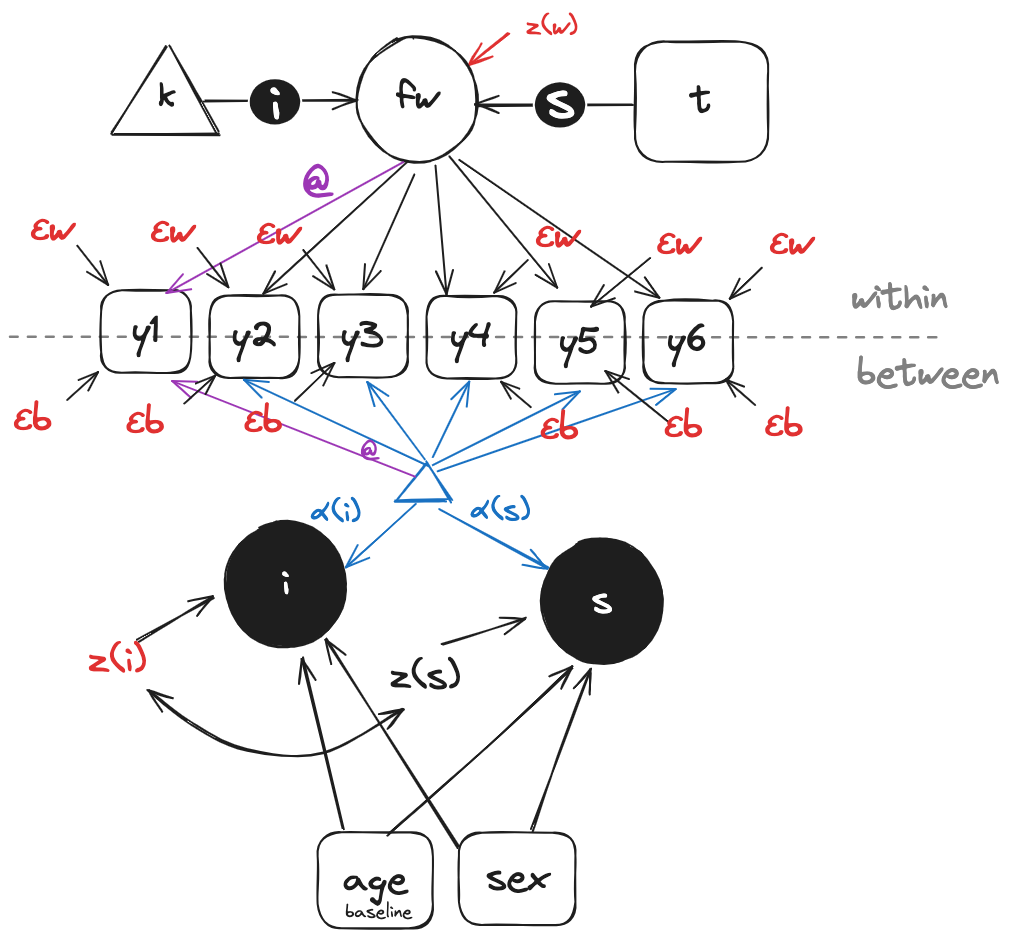

This is the model set-up for the multilevel growth-of-factors model. This model is conceptually similar to the MLFA model, although we remove the BETWEEN level factor model for the items, and we “trick” Mplus into estimating a random intercept for the latent factor at the between level by regressing it on a constant (k) and declaring that regression to be random.

As with the MLFA model, observed indicators of depression (y1-y6) are both within and between level variables (and not specified as WITHIN or BETWEEN in Mplus input). A within-level factor is specified (fw) that is identified by fixing the first factor loading (as described in the MLFA model; fixed parameters are shown in purlple). fw is regressed on time and this is declared a random effect and assigned the label “s”. fw is regressed on a constant variable “k”, and this is also declared random and assigned the label “i”.

At the between level, we model the item intercepts (fixing the first item’s intercept as described in the MLFA model to identify the mean of i) and the between-level residual variances of y1-y6 are fixed to 0, for reasons described in MLFA model setup.

**Data setup**

Use MplusAutomation to prepare data set for Mplus. You actually have to compute the constant and add it to the data set output to Mplus.

```r
# add constant to data frame
df.cesd$k <- 1
MplusAutomation::prepareMplusData(df.cesd,"cesdlongk.dat")
```

```
TITLE: Your title goes here
DATA: FILE = "cesdlongk.dat";
VARIABLE:
NAMES = id td female agec70 y1 y2 y3 y4 y5 y6 k;
MISSING=.;
```

## Mplus MLGOF model

**Multilevel Growth of Factors** is what I’m calling this model

```
TITLE:    Growth of Factors MLM
DATA:     FILE = cesdlongk.dat ;
          VARIANCES = NOCHECK ; ! this is critical b/c of k
VARIABLE: NAMES = id td female agec70 y1 y2 y3 y4 y5 y6 k ;
          MISSING = . ;
          WITHIN = td k ;
          BETWEEN = agec70 female ;
          CLUSTER = id ;
ANALYSIS: TYPE = TWOLEVEL RANDOM ;
MODEL:    %WITHIN%
            fw BY y1@0.51150 (l1);
            fw by y2-y6* (l2-l6);
            s | fw on td ; ! random slope with respect to td
            i | fw on k ; ! random intercept (constant)
          %BETWEEN%
            i s on agec70 female ;
            i with s ;
            y1-y6@0 ; ! force all residual variance to within or i, s
            [y1@1.35775]; ! needed for identification of intercept(i)
            [y2-y6*];
```

```
Mplus VERSION 8.11 (Mac)
MUTHEN & MUTHEN
05/03/2025  12:55 PM

INPUT INSTRUCTIONS

  TITLE:    Growth of Factors MLM
  DATA:     FILE = cesdlongk.dat ;
            VARIANCES = NOCHECK ; ! this is critical b/c of k
  VARIABLE: NAMES = id td female agec70 y1 y2 y3 y4 y5 y6 k ;
            MISSING = . ;
            WITHIN = td k ;
            BETWEEN = agec70 female ;
            CLUSTER = id ;
  ANALYSIS: TYPE = TWOLEVEL RANDOM ;
  MODEL:    %WITHIN%
              fw BY y1@0.51150 (l1);
              fw by y2-y6* (l2-l6);
              s | fw on td ; ! random slope with respect to td
              i | fw on k ; ! random intercept (constant)
            %BETWEEN%
              i s on agec70 female ;
              i with s ;
              y1-y6@0 ; ! force all residual variance to within or i, s
              [y1@1.35775]; ! needed for identification of intercept(i)
              [y2-y6*];




*** WARNING
  One or more individual-level variables have no variation within a
  cluster for the following clusters.

     Variable   Cluster IDs with no within-cluster variation

      Y1          154 319 484 815 1046 1528 1791 2164 2451 557 98
      Y2          687 793 1071 1618 1669 2096 2104 2369 557 2205
      Y3          154 2369
      Y4          154 319 484 605 815 1012 1046 1528 1786 1849 2549 557 98
```

[output cut: 223 more lines]

```
        Ending Time:  12:55:18
       Elapsed Time:  00:00:01



MUTHEN & MUTHEN
3463 Stoner Ave.
Los Angeles, CA  90066

Tel: (310) 391-9971
Fax: (310) 391-8971
Web: www.StatModel.com
Support: Support@StatModel.com

Copyright (c) 1998-2024 Muthen & Muthen
```

**Save output**

```r
file.copy("formplus.out", "401-mlgof.out", overwrite = TRUE)
```

```
[1] TRUE
```

```r
file.copy("formplus.inp", "401-mlgof.inp", overwrite = TRUE)
```

```
[1] TRUE
```

```r
mlgofResults <- MplusAutomation::readModels(target="401-mlgof.out")
mlgof_parameters <-  mlgofResults$parameters$unstandardized %>%
   mutate(PARAMETER = str_c(paramHeader,param, sep = " "))
```

# Multiple Indicator LGCM

## Modeling considerations: MILGCM

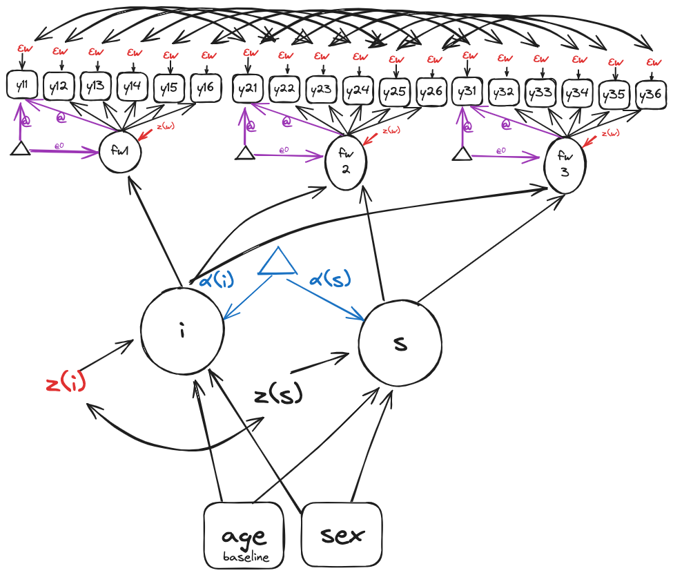

This is the model set-up for the multiple indicators LGCM. It’s too much of a model for the Mplus DEMO version, as in our case it will involve 18 dependent variables (y1-y6 at each of 3 observations). These models are challenging to specify properly, and can take a long time to estimate with maximum likelihood methods because of the relatively large number of latent variables over which to integrate.

But, with only 3 observation time points, it is not too onerous to specify this model, and provides a useful comparison to our multilevel approaches.

I will use constraints on y1 (intercepts and measurement slopes) as in previous multilevel models to place the results on a comparable scale.

**Data setup**

```r
items <- c("sad", "blues", "depress", "happy", "enjoy", "hopeful")
df.cesd <- df %>%
      select(which(names(df) %in% c("id", "t",items,"agec70","female")))
# Create new variables y1-y6 that correspond to the variables in items
for (i in seq_along(items)) {
  df.cesd[[paste0("y", i)]] <- df.cesd[[items[i]]]
}
df.cesd <- df.cesd %>%  select(-all_of(items))


# Convert 't' into a factor to prevent it from being treated as a function
df.cesd$t <- as.factor(df.cesd$t)

# Reshape the dataframe to long format
long_df <- df.cesd %>%
  pivot_longer(
    cols = starts_with("y"),
    names_to = "y",
    values_to = "y_values"
  ) %>%
  # Ensure each combination of id and t has a unique row for each y
  group_by(id, t) %>%
  mutate(y_number = row_number()) %>%
  ungroup()

# Create a time variable that interacts with 'y_number' and 't'
long_df <- long_df %>%
  mutate(y_time = paste0("y", t, y_number))

# Then, reshape back to wide format with new names for 'y' variables
wide_df <- long_df %>%
  pivot_wider(
    id_cols = c(id, female, agec70),
    names_from = y_time,
    values_from = y_values,
    names_prefix = ""
  )
```

**View the resulting dataframe**

```
# A tibble: 6 × 21
     id female agec70   y01   y02   y03   y04   y05   y06   y31   y32   y33
  <int>  <int>  <dbl> <int> <int> <int> <int> <int> <int> <int> <int> <int>
1     1      0    1.7     2     2     2     3     3     3    NA    NA    NA
2     2      1    1.7     1     1     1     1     1     1     2     1     1
3     3      1    1.2     2     1     1     3     3     4     2     1     2
4     4      0    1.2     1     1     1     1     1     1     1     1     1
5     5      1    1.2    NA     1     2    NA    NA    NA     1     1     1
6     6      0    1.2     1     1     1     1     1     4    NA    NA    NA
# ℹ 9 more variables: y34 <int>, y35 <int>, y36 <int>, y61 <int>, y62 <int>,
#   y63 <int>, y64 <int>, y65 <int>, y66 <int>
```

**Use MplusAutomation to generate data for Mplus**

```r
MplusAutomation::prepareMplusData(wide_df,"cesdwide.dat")
```

```
TITLE: Your title goes here
DATA: FILE = "cesdwide.dat";
VARIABLE:
NAMES = id female agec70 y01 y02 y03 y04 y05 y06 y31 y32 y33 y34 y35 y36 y61 y62 y63
     y64 y65 y66;
MISSING=.;
```

## Mplus MILGCM

```
TITLE:    LGCM CESD score
DATA:     FILE = "cesdwide.dat";
VARIABLE: NAMES = id female agec70
          y01 y02 y03 y04 y05 y06
          y31 y32 y33 y34 y35 y36
          y61 y62 y63 y64 y65 y66;
          IDVARIABLE = id ;
          MISSING = . ;
MODEL:    fw0 BY y01@0.51150 (l1);
          fw3 BY y31@0.51150 (l1);
          fw6 BY y61@0.51150 (l1);
          fw0 by y02-y06* (l2-l6);
          fw3 by y32-y36* (l2-l6);
          fw6 by y62-y66* (l2-l6);
          [y01@1.35775];
          [y31@1.35775];
          [y61@1.35775];
          [y02-y06*] (nu2-nu6) ;
          [y32-y36*] (nu2-nu6) ;
          [y62-y66*] (nu2-nu6) ;
          y01 y31 y61 (te1) ;
          y02 y32 y62 (te2) ;
          y03 y33 y63 (te3) ;
          y04 y34 y64 (te4) ;
          y05 y35 y65 (te5) ;
          y06 y36 y66 (te6) ;
          y01 with y31 (te11) ;
          y31 with y61 (te11) ;
          y02 with y32 (te22) ;
          y32 with y62 (te22) ;
          y03 with y33 (te33) ;
          y33 with y63 (te33) ;
          y04 with y34 (te44) ;
          y34 with y64 (te44) ;
          y05 with y35 (te55) ;
          y35 with y65 (te55) ;
          y06 with y36 (te66) ;
          y36 with y66 (te66) ;
          y01 with y61  ;
          y02 with y62  ;
          y03 with y63  ;
          y04 with y64  ;
          y05 with y65  ;
          y06 with y66  ;
          [fw0@0] ;
          [fw3@0] ;
          [fw6@0] ;
          fw0* (psi1) ;
          fw3* (psi1) ;
          fw6* (psi1) ;
          i by fw0-fw6@1 ;
          s by fw0@0 fw3@0.3 fw6@0.6 ; ! per decade
          i with s ;
          i s on agec70 female ;
          [i*] ;
          [s*] ;
```

```
Mplus VERSION 8.11 (Mac)
MUTHEN & MUTHEN
05/03/2025  12:55 PM

INPUT INSTRUCTIONS

  TITLE:    LGCM CESD score
  DATA:     FILE = "cesdwide.dat";
  VARIABLE: NAMES = id female agec70
            y01 y02 y03 y04 y05 y06
            y31 y32 y33 y34 y35 y36
            y61 y62 y63 y64 y65 y66;
            IDVARIABLE = id ;
            MISSING = . ;
  MODEL:    fw0 BY y01@0.51150 (l1);
            fw3 BY y31@0.51150 (l1);
            fw6 BY y61@0.51150 (l1);
            fw0 by y02-y06* (l2-l6);
            fw3 by y32-y36* (l2-l6);
            fw6 by y62-y66* (l2-l6);
            [y01@1.35775];
            [y31@1.35775];
            [y61@1.35775];
            [y02-y06*] (nu2-nu6) ;
            [y32-y36*] (nu2-nu6) ;
            [y62-y66*] (nu2-nu6) ;
            y01 y31 y61 (te1) ;
            y02 y32 y62 (te2) ;
            y03 y33 y63 (te3) ;
            y04 y34 y64 (te4) ;
            y05 y35 y65 (te5) ;
            y06 y36 y66 (te6) ;
            y01 with y31 (te11) ;
            y31 with y61 (te11) ;
            y02 with y32 (te22) ;
            y32 with y62 (te22) ;
            y03 with y33 (te33) ;
            y33 with y63 (te33) ;
            y04 with y34 (te44) ;
            y34 with y64 (te44) ;
```

[output cut: 397 more lines]

```
        Ending Time:  12:55:19
       Elapsed Time:  00:00:01



MUTHEN & MUTHEN
3463 Stoner Ave.
Los Angeles, CA  90066

Tel: (310) 391-9971
Fax: (310) 391-8971
Web: www.StatModel.com
Support: Support@StatModel.com

Copyright (c) 1998-2024 Muthen & Muthen
```

**Save output from Mplus Engine**

```r
file.copy("formplus.out", "401-milgcm.out", overwrite = TRUE)
file.copy("formplus.inp", "401-milgcm.inp", overwrite = TRUE)
milgcmResults <- MplusAutomation::readModels(target="401-milgcm.out")
milgcm_parameters <-  milgcmResults$parameters$unstandardized %>%
   mutate(PARAMETER = str_c(paramHeader,param, sep = " "))
```

```
Mplus VERSION 8.11 (Mac)
MUTHEN & MUTHEN
05/03/2025  12:55 PM

INPUT INSTRUCTIONS

  TITLE:    LGCM CESD score
  DATA:     FILE = "cesdwide.dat";
  VARIABLE: NAMES = id female agec70
            y01 y02 y03 y04 y05 y06
            y31 y32 y33 y34 y35 y36
            y61 y62 y63 y64 y65 y66;
            IDVARIABLE = id ;
            MISSING = . ;
  MODEL:    fw0 BY y01@0.51150 (l1);
            fw3 BY y31@0.51150 (l1);
            fw6 BY y61@0.51150 (l1);
            fw0 by y02-y06* (l2-l6);
            fw3 by y32-y36* (l2-l6);
            fw6 by y62-y66* (l2-l6);
            [y01@1.35775];
            [y31@1.35775];
            [y61@1.35775];
            [y02-y06*] (nu2-nu6) ;
            [y32-y36*] (nu2-nu6) ;
            [y62-y66*] (nu2-nu6) ;
            y01 y31 y61 (te1) ;
            y02 y32 y62 (te2) ;
            y03 y33 y63 (te3) ;
            y04 y34 y64 (te4) ;
            y05 y35 y65 (te5) ;
            y06 y36 y66 (te6) ;
            ! y01 with y31 (te11) ;
            ! y31 with y61 (te11) ;
            ! y02 with y32 (te22) ;
            ! y32 with y62 (te22) ;
            ! y03 with y33 (te33) ;
            ! y33 with y63 (te33) ;
            ! y04 with y34 (te44) ;
            ! y34 with y64 (te44) ;
```

[output cut: 355 more lines]

```
        Ending Time:  12:55:19
       Elapsed Time:  00:00:00



MUTHEN & MUTHEN
3463 Stoner Ave.
Los Angeles, CA  90066

Tel: (310) 391-9971
Fax: (310) 391-8971
Web: www.StatModel.com
Support: Support@StatModel.com

Copyright (c) 1998-2024 Muthen & Muthen
```

# Model comparisons of like parameters

In the remainder of this presentation I will tabulate comparable parameter estimates from the various models we have considered

**Table 1. Growth model levels and slopes: intercept estimates**

| Model | Level | se | Slope | se |
| --- | --- | --- | --- | --- |
| MLM(Yz) | -0.177 | 0.027 | 0.196 | 0.069 |
| MLCFA | -0.005 | 0.031 | 0.184 | 0.074 |
| MLGOF | -0.005 | 0.031 | 0.184 | 0.074 |
| MILGCM | -0.008 | 0.036 | 0.187 | 0.083 |

**Table 2. Growth model levels and slopes: residual variances**

| Model | Level | se | Slope | se |
| --- | --- | --- | --- | --- |
| MLM(Yz) | 0.4 | 0.04 | 0.328 | 0.22 |
| MLCFA | 0.5 | 0.058 | 0.177 | 0.296 |
| MLGOF | 0.5 | 0.058 | 0.178 | 0.296 |
| MILGCM | 0.482 | 0.042 | 0.146 | 0.231 |

MLM(Yz) residual variances are from the BETWEEN model part.

**Table 3. Growth model LEVEL parameter: effect of `agec70` and `female` sex**

| Model | `agec70` | se | `female` | se |
| --- | --- | --- | --- | --- |
| MLM(Yz) | 0.113 | 0.03 | 0.217 | 0.036 |
| MLCFA | 0.103 | 0.033 | 0.263 | 0.041 |
| MLGOF | 0.103 | 0.033 | 0.263 | 0.041 |
| MILGCM | 0.104 | 0.032 | 0.265 | 0.042 |

**Table 4. Growth model SLOPE parameter: effect of `agec70` and `female` sex**

| Model | `agec70` | se | `female` | se |
| --- | --- | --- | --- | --- |
| MLM(Yz) | 0.158 | 0.083 | -0.013 | 0.091 |
| MLCFA | 0.206 | 0.095 | 0.039 | 0.1 |
| MLGOF | 0.206 | 0.095 | 0.039 | 0.1 |
| MILGCM | 0.205 | 0.087 | 0.038 | 0.104 |

**Table 5. Residual covariance of LEVEL and SLOPE**

| Model | est | se |
| --- | --- | --- |
| MLM(Yz) | -0.046 | 0.075 |
| MLCFA | 0 | 0.101 |
| MLGOF | 0 | 0.101 |
| MILGCM | 0.009 | 0.078 |

**Table 6. Fit information**

|  | MLFA | MLGOF | MILGCM no rescov | MILGCM |
| --- | --- | --- | --- | --- |
| Observations | 6165 | 6165 | 2762 | 2762 |
| Parameters | 26 | 26 | 26 | 38 |
| LL | -42123.918 | -42123.918 | -42124.312 | -42032.198 |
| LLCorrectionFactor | 1.6585 | 1.6585 | NA | NA |
| AIC | 84299.835 | 84299.835 | 84300.624 | 84140.396 |
| BIC | 84474.728 | 84474.728 | 84454.64 | 84365.497 |
| elapsed_time | 00:00:01 | 00:00:01 | 00:00:00 | 00:00:01 |

The multilevel confirmatory factor analysis (MLCFA) and multilevel growth of factors (MLGOF) models, as I have parameterized them, are equivalent. The MILGCM (no rescov) [the MILGCM model without the item-level residual covariances over time] has a very similar LL to these two models as well. The MILGCM provides the best fit according to loglikelihood (LL). The $\chi^2$ difference test on LL for the MILGCM (no rescov) relative to MILGCM model indicates the residual covariances provide significant improvement in model fit ($\chi^2 = 184, \text{df} = 12, P < .001$).

Notes:  
(1) As discussed previously, *BIC from “wide” and “long” data layouts are not comparable.*  
(2) The multilevel model for the observed composite CESD score, MLM(Yz), is not comparable to the other models in terms of fit, and therefore is not tabulated.

(fin)

[figure not shown]